# ExpressAnalystR

- Description
- Installation
  - 1. Install package dependencies
  - 2. Install the package
- Tips for using the ExpressAnalystR package
- Examples
  - 1. Starting from a gene expression matrix
    - 1.1 Load ExpressAnalystR library and initialize R objects
    - 1.2 Read data table
    - 1.3 Annotate gene IDs to Entrez
    - 1.4 Perform data filtering and normalization
    - 1.5 Prepare differential expression (DE) analysis
    - 1.6 Perform DE analysis and check DE results
    - 1.7 Visualize gene expression pattern of individual gene
  - 2. Starting from three datasets for meta-analysis
    - 2.1 Load ExpressAnalystR library and initialize R objects
    - 2.2 Process each individual dataset
    - 2.3 Perform data integrity check (compatibility)
    - 2.4 Check diagnostic plot and perform batch correction
    - 2.5 Perform statistical meta-analysis using combine p-values method
    - 2.6 View result tables

## Description

*ExpressAnalystR* is the underlying R package synchronized with ExpressAnalyst web server. It is designed for statistical analysis, enrichment analysis and visual analytics of single and multiple gene expression data, both matrix and gene list. The R package is composed of R functions necessary for the web-server to perform data annotation, normalization, differential expression and meta-analysis.

Following installation and loading of ExpressAnalystR, users will be able to reproduce web server results from their local computers using the R command history downloaded from ExpressAnalystR. Running the R functions will allow more flexibility and reproducibility.

Note - ExpressAnalystR is still under development - we cannot guarantee full functionality

## Installation

### 1. Install package dependencies

To use ExpressAnalystR, make sure your R version is >4.0.3 and install all package dependencies. Ensure that you are able to download packages from Bioconductor. To install package dependencies, use the pacman R package. Note that some of these packages may require additional library dependencies that need to be installed prior to their own successful installation.

```r
install.packages("pacman")

library(pacman)

pacman::p_load(igraph, RColorBrewer, qs, rjson, RSQLite)
```

### 2. Install the package

ExpressAnalystR is freely available from GitHub. The package documentation, including the vignettes for each module and user manual is available within the downloaded R package file. If all package dependencies were installed, you will be able to install the ExpressAnalystR.

Install the package directly from github using the *devtools* package. Open R and enter:

```r
# Step 1: Install devtools
install.packages('devtools')
library(devtools)

# Step 2: Install ExpressAnalystR WITHOUT documentation
devtools::install_github("xia-lab/ExpressAnalystR", build = TRUE, build_opts = c("--no-resave-data", "--no-manual", "--no-build-vignettes"))

# Step 2: Install ExpressAnalystR WITH documentation
devtools::install_github("xia-lab/ExpressAnalystR", build = TRUE, build_opts = c("--no-resave-data", "--no-manual"), build_vignettes = TRUE)
```

## Tips for using the ExpressAnalystR package

1. The first function that you will use in every module is the `Init.Data` function, which initiates R objects that stores user’s data, parameters for further processing and analysis.
2. The ExpressAnalystR package will output data files/tables/analysis/networks outputs in your current working directory.
3. Every function must be executed in sequence as it is shown on the R Command history, please do not skip any commands as this can result in errors downstream.
4. Main functions in ExpressAnalystR are documented. Use the *?Function* format to open its documentation. For instance, use `?ExpressAnalystR::ReadTabExpression` to find out more about this function.
5. It is recommended to set the working folder to an empty folder because numerous files will be generated through the process.
6. R package is not useful for visual analytics as they are hosted on the website. It’s mainly useful for statistical analysis (differential expression and meta-analysis).
7. R package is derived from R scripts used for powering web server. The values returned are often not useful in the context of local usage. The results from R functions are saved in a format qs file named as the file name of original data table. For gene list, the format qs file is named “datalist1”. use this function to access: `dataSet <- readDataset(fileName)`

## Examples

### 1. Starting from a gene expression matrix

```r
library(ExpressAnalystR)

#boolean FALSE indicates local mode (vs web mode);
Init.Data(FALSE);

# Set analysis type to single gene expression matrix
SetAnalType("onedata");
```

#### 1.2 Read data table

```r
dataName <- "endotoxin_data.txt";
dataSets <- ReadTabExpressData(dataName);
```

#### 1.3 Annotate gene IDs to Entrez

For this step it is imortant to please select correct organism, data type (array or RNA-seq), id type and gene-level summary (mean, median, sum). For gene-level summary, microarray can use mean or median while RNA-seq needs to be sum.

```r
dataSets <- PerformDataAnnot(dataName, "hsa", "array", "refseq", "mean");
```

Take a look at the mapped dataset by reading the dataset’s qs file using `readDataset(fileName)` function.

```r
dataSet <- readDataset(dataName)
print(head(dataSet$data.anot[c(1:5),]))
```

Check diagnostics plots to look at overall data distribution, sample separation.

```r
PlotDataBox(dataName, "qc_boxplot_", 72, "png");
PlotDataPCA(dataName, "qc_pca_", 72, "png");
```

Check your working directory for png images named `qc_boxplot_dpi72.png` and `qc_pca_dpi72.png`, open them.

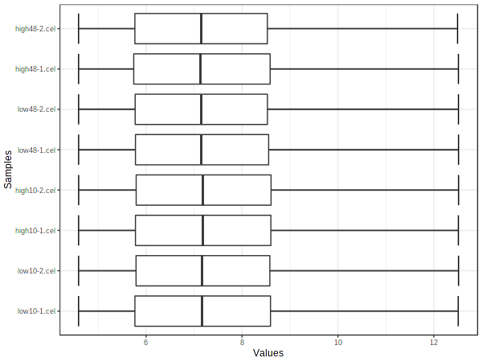

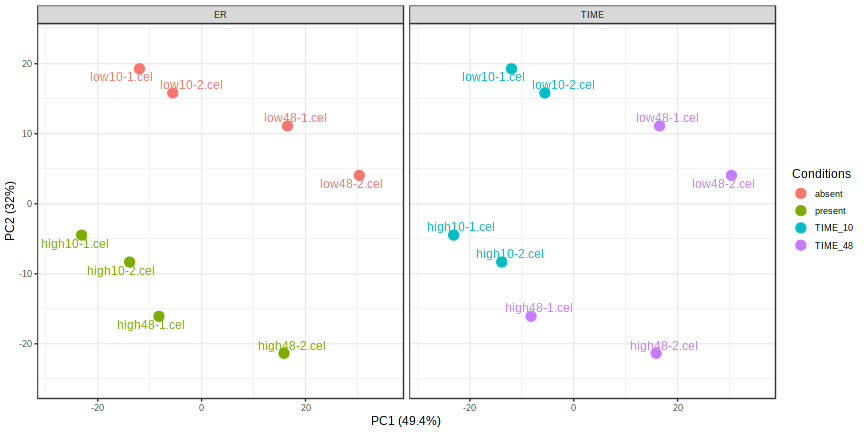

#### 1.4 Perform data filtering and normalization

```r
dataSets <- PerformNormalization("endotoxin_data.txt", "none", 15, 4,"true","false");
```

#### 1.5 Prepare differential expression (DE) analysis

```r
dataSets <- SetSelectedMetaInfo(dataName,"Treatment", "NA", F);
dataSets <- SetupDesignMatrix(dataName, "limma");
```

#### 1.6 Perform DE analysis and check DE results

Fold change is log2 transformed. Adjusted P-value using False Discovery Rate (FDR) method.

```r
dataSets <- PerformDEAnal(dataName, "custom", "control vs. LPS", "NA", "intonly");
dataSet <- readDataset(dataName);
print(head(dataSet$comp.res));
```

#### 1.7 Visualize gene expression pattern of individual gene

```r
PlotSelectedGene(dataName,"Gene_5111_","5111", dpi=72, format="png");
```

Check the resulting png image (Gene_5111_dpi72.png) in your working directory.

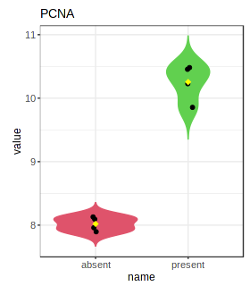

### 2. Starting from three datasets for meta-analysis

Before you start, please download the example datasets into your working directory [E-GEOD-25713](https://dev.expressanalyst.ca/resources/data/test/E-GEOD-25713.txt), E-GEOD-59276.txt, GSE69588.txt. These three testing datasets (containing subset of 5000 genes) are from a meta-analysis of helminth infections in mouse liver.

#### 2.1 Load ExpressAnalystR library and initialize R objects

```r
library(ExpressAnalystR)

#boolean FALSE indicates local mode (vs web mode);
Init.Data(FALSE);

# Set analysis type to meta-analysis
SetAnalType("metadata");
```

#### 2.2 Read and process individual dataset

```r
#Read dataset text file
dataSets <- ReadOmicsData("E-GEOD-25713.txt");
dataSets <- ReadOmicsData("E-GEOD-59276.txt");
dataSets <- ReadOmicsData("GSE69588.txt");

ReadMetaData("helminth_meta.csv");

dataSets <- SanityCheckData("E-GEOD-25713.txt");

#Map gene id to entrez id
dataSets <- AnnotateGeneData("E-GEOD-25713.txt", "mmu", "mean","entrez");
```

Visually inspect dataset using box plot (`qc_boxplot_0_dpi72.png`) and pca plot (`qc_pca_0_dpi72.png`).

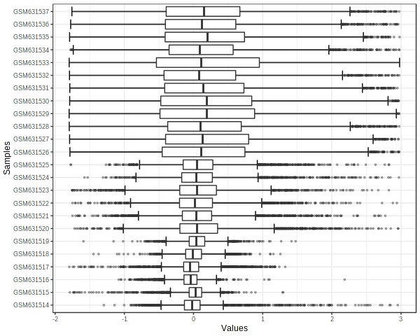

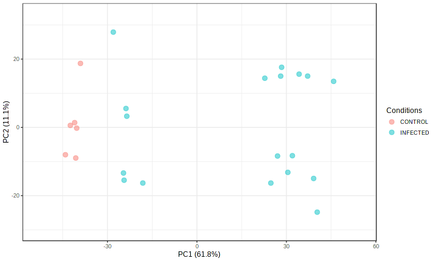

```r
PlotDataProfile("E-GEOD-25713.txt", "raw", "qc_boxplot_0_", "qc_pca_0_");
```

```r
#Remove variables with more than 50% missing data
dataSets <- RemoveMissingPercent("E-GEOD-25713.txt", 0.5);

#Replace missing value with minimum values across dataset
dataSets <- ImputeMissingVar("E-GEOD-25713.txt", "min");

#Replace missing value with minimum values across dataset
dataSets <- FilteringData("E-GEOD-25713.txt","pct","0", "0");
dataSets <- NormalizeDataMetaMode("E-GEOD-25713.txt", "NA");

#process the other two datasets
dataSets <- SanityCheckData("E-GEOD-59276.txt");
dataSets <- AnnotateGeneData("E-GEOD-59276.txt", "mmu","mean", "entrez");
dataSets <- RemoveMissingPercent("E-GEOD-59276.txt", 0.5);
dataSets <- ImputeMissingVar("E-GEOD-59276.txt", "min");
dataSets <- FilteringData("E-GEOD-59276.txt","pct","0", "0");
dataSets <- NormalizeDataMetaMode("E-GEOD-59276.txt", "NA");

dataSets <- SanityCheckData("GSE69588.txt");
dataSets <- AnnotateGeneData("GSE69588.txt", "mmu","mean", "entrez");
dataSets <- RemoveMissingPercent("GSE69588.txt", 0.5);
dataSets <- ImputeMissingVar("GSE69588.txt", "min");
dataSets <- FilteringData("GSE69588.txt","pct","0", "0");
dataSets <- NormalizeDataMetaMode("GSE69588.txt", "NA");
```

#### 2.3 Perform data integrity check (compatibility)

```r
CheckMetaDataIntegrity();
```

#### 2.4 Check diagnostic plot and perform batch correction

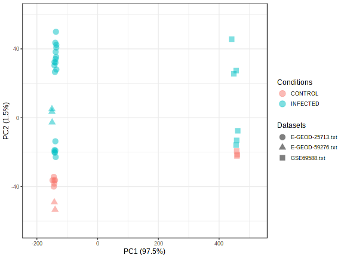

```r
PlotMetaPCA("qc_meta_pca_","72", "png", "");
```

There is clear signs of batch effect. The samples from same dataset are largely clustered together. To remove the batch effect, we need to run comBat batch correction algorithm

```r
#Apply batch effect correction
dataSets <- PerformBatchCorrection();

#Check the result
PlotMetaPCA("qc_meta_pca_afterBatch_","72", "png", "");
```

Here is the result after batch correction.

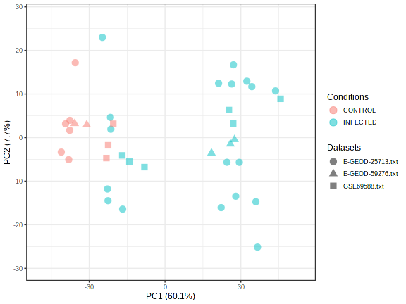

#### 2.5 Perform DE analysis

```r
CovariateScatter.Anal("E-GEOD-25713.txt", "E-GEOD-25713.txt_covariate_0_.png", "png", "Condition", "CONTROL", "NA" , 0.05,"fdr", "anova")
CovariateScatter.Anal("E-GEOD-59276.txt", "E-GEOD-59276.txt_covariate_0_.png", "png", "Condition", "CONTROL", "NA" , 0.05,"fdr", "anova")
CovariateScatter.Anal("GSE69588.txt", "GSE69588.txt_covariate_0_.png", "png", "Condition", "CONTROL", "NA" , 0.05,"fdr", "anova")
```

#### 2.5 Perform statistical meta-analysis using combine p-values method

```r
PerformPvalCombination("fisher", 0.05)
```

#### 2.6 View result tables

```r
analSet <- readSet(analSet, "analSet");
print(head(analSet$meta.mat));
#
#       CombinedTstat CombinedPval
#16854         89.093   2.7728e-14
#246256        99.964   2.7728e-14
#105855        94.751   2.7728e-14
#19241        105.030   2.7728e-14
#319169        94.339   2.7728e-14
#16819        100.880   2.7728e-14
```

For a more detailed table containing additionally log fold change and p-values of features for individual dataset, please check this csv file meta_sig_genes_metap.csv, it is also generated in your working directory.